# Exploratory data analysis using statistical techniques

Leveraging customer information is paramount for most businesses. In the case of an insurance company, attributes of customers like the ones mentioned below can be crucial in making business decisions. Hence, knowing to explore and generate value out of such data can be an invaluable skill to have.

# 1. Import the necessary libraries (2 marks)

```python
'''Importing Data Manipulattion Moduls'''
import numpy as np
import pandas as pd

'''Seaborn and Matplotlib Visualization'''
import matplotlib.pyplot as plt
import seaborn as sns
%matplotlib inline
```

# 2. Read the data as a data frame (2 marks)

```python
data = pd.read_csv('insurance.csv')
len(data)
```

```
1338
```

```python
data.head(5)
```

|  | age | sex | bmi | children | smoker | region | charges |
| --- | --- | --- | --- | --- | --- | --- | --- |
| 0 | 19 | female | 27.900 | 0 | yes | southwest | 16884.92400 |
| 1 | 18 | male | 33.770 | 1 | no | southeast | 1725.55230 |
| 2 | 28 | male | 33.000 | 3 | no | southeast | 4449.46200 |
| 3 | 33 | male | 22.705 | 0 | no | northwest | 21984.47061 |
| 4 | 32 | male | 28.880 | 0 | no | northwest | 3866.85520 |

# Perform basic EDA which should include the following and print out your insights at every step. (28 marks)

```python
#a) Shape of the data (2 marks)
print('Dimensions of train data:', data.shape)
```

```
Dimensions of train data: (1338, 7)
```

```python
#b) Data type of each attribute (2 marks)
data.dtypes
```

```
age           int64
sex          object
bmi         float64
children      int64
smoker       object
region       object
charges     float64
dtype: object
```

```python
#c) Checking the presence of missing values (3 marks)
''' count of missing values column wise'''
data.isnull().sum()
```

```
age         0
sex         0
bmi         0
children    0
smoker      0
region      0
charges     0
dtype: int64
```

Hence, no missing value is present in this data

```python
#d) 5 point summary of numerical attributes (3 marks)

print("Summary of Age")
print(data['age'].describe())
print("\n\n")


print("Summary of BMI")
print(data['bmi'].describe())
print("\n\n")

print("Summary of Children")
print(data['children'].describe())
print("\n\n")

print("Summary of Charges")
print(data['charges'].describe())
print("\n\n")
```

```
Summary of Age
count    1338.000000
mean       39.207025
std        14.049960
min        18.000000
25%        27.000000
50%        39.000000
75%        51.000000
max        64.000000
Name: age, dtype: float64



Summary of BMI
count    1338.000000
mean       30.663397
std         6.098187
min        15.960000
25%        26.296250
50%        30.400000
75%        34.693750
max        53.130000
Name: bmi, dtype: float64



Summary of Children
count    1338.000000
mean        1.094918
std         1.205493
min         0.000000
25%         0.000000
50%         1.000000
75%         2.000000
max         5.000000
Name: children, dtype: float64



Summary of Charges
count     1338.000000
mean     13270.422265
std      12110.011237
min       1121.873900
25%       4740.287150
50%       9382.033000
75%      16639.912515
max      63770.428010
Name: charges, dtype: float64
```

|  | age | bmi | charges |
| --- | --- | --- | --- |
| 0 | 19 | 27.90 | 16884.9240 |
| 1 | 18 | 33.77 | 1725.5523 |
| 2 | 28 | 33.00 | 4449.4620 |

```
array(['age', 'bmi', 'charges'], dtype=object)
```

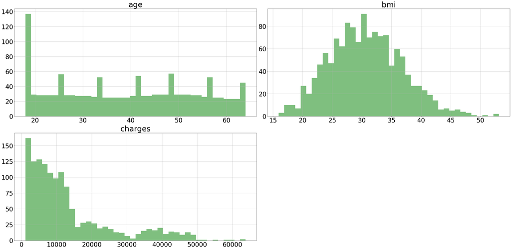

```python
#e) Distribution of ‘bmi’, ‘age’ and ‘charges’ columns. (4 marks)

def draw_histograms(df, variables, n_rows, n_cols):
    fig=plt.figure()
    for i, var_name in enumerate(variables):
        ax=fig.add_subplot(n_rows,n_cols,i+1)
        df[var_name].hist(bins=40,ax=ax,color = 'green',alpha=0.5, figsize = (40, 200))
        ax.set_title(var_name, fontsize = 43)
        ax.tick_params(axis = 'both', which = 'major', labelsize = 35)
        ax.tick_params(axis = 'both', which = 'minor', labelsize = 35)
        ax.set_xlabel('')
    fig.tight_layout(rect = [0, 0.03, 1, 0.95])  # Improves appearance a bit.
    plt.show()


'''Extracting numerical variables first'''
num_merged = data.select_dtypes(include = ['int64', 'float64'])
del num_merged["children"]
display(num_merged.head(3))
print('\n')
display(num_merged.columns.values)
draw_histograms(num_merged, num_merged.columns, 19, 2)
```

```python
#f) Measure of skewness of ‘bmi’, ‘age’ and ‘charges’ columns (2 marks)
'''Skewness and Kurtosis of SalePrice'''
print("Skewness of bmi : %f" % data["bmi"].skew())
print("Skewness of age: %f" % data["age"].skew())
print("Skewness of charges: %f" % data["charges"].skew())
```

```
Skewness of bmi : 0.284047
Skewness of age: 0.055673
Skewness of charges: 1.515880
```

```python
#g. Checking the presence of outliers in ‘bmi’, ‘age’ and ‘charges columns (4 marks)

bmi_low = data["bmi"].quantile(0.1)
bmi_hi  = data["bmi"].quantile(0.9)
print("Lower BMI threshold :", bmi_low)
print("Higher BMI threshold :",bmi_hi )
bmi_outliers = data["bmi"][(data["bmi"] < bmi_hi) & (data["bmi"] > bmi_low)]
print(bmi_outliers)
```

```
Lower BMI threshold : 22.99
Higher BMI threshold : 38.619499999999995
0       27.90
1       33.77
2       33.00
4       28.88
5       25.74
        ...
1333    30.97
1334    31.92
1335    36.85
1336    25.80
1337    29.07
Name: bmi, Length: 1068, dtype: float64
```

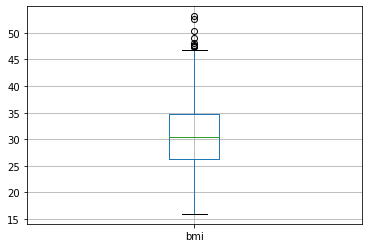

```python
boxplot = data.boxplot(column=['bmi'])
```

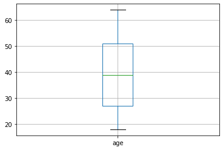

```python
boxplot = data.boxplot(column=['age'])
```

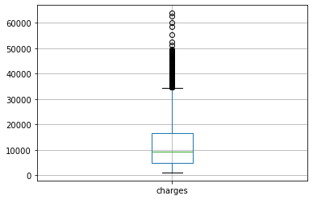

```python
boxplot = data.boxplot(column=['charges'])
```

```python
Q1 = data['bmi'].quantile(0.25)
Q3 = data['bmi'].quantile(0.75)
IQR = Q3 - Q1    #IQR is interquartile range.

filter = (data['bmi'] >= Q1 - 1.5 * IQR) & (data['bmi'] <= Q3 + 1.5 *IQR)
print("Number of outliers in BMI :",len(data)-len(data.loc[filter]))
```

```
Number of outliers in BMI : 9
```

```python
Q1 = data['age'].quantile(0.25)
Q3 = data['age'].quantile(0.75)
IQR = Q3 - Q1    #IQR is interquartile range.

filter = (data['age'] >= Q1 - 1.5 * IQR) & (data['age'] <= Q3 + 1.5 *IQR)
print("Number of outliers in Age :",len(data)-len(data.loc[filter]))
```

```
Number of outliers in Age : 0
```

```python
Q1 = data['charges'].quantile(0.25)
Q3 = data['charges'].quantile(0.75)
IQR = Q3 - Q1    #IQR is interquartile range.

filter = (data['charges'] >= Q1 - 1.5 * IQR) & (data['charges'] <= Q3 + 1.5 *IQR)
print("Number of outliers in Charges :",len(data)-len(data.loc[filter]))
```

```
Number of outliers in Charges : 139
```

|  | sex | smoker | region | children |
| --- | --- | --- | --- | --- |
| 0 | female | yes | southwest | 0 |
| 1 | male | no | southeast | 1 |
| 2 | male | no | southeast | 3 |

```
array(['sex', 'smoker', 'region', 'children'], dtype=object)
```

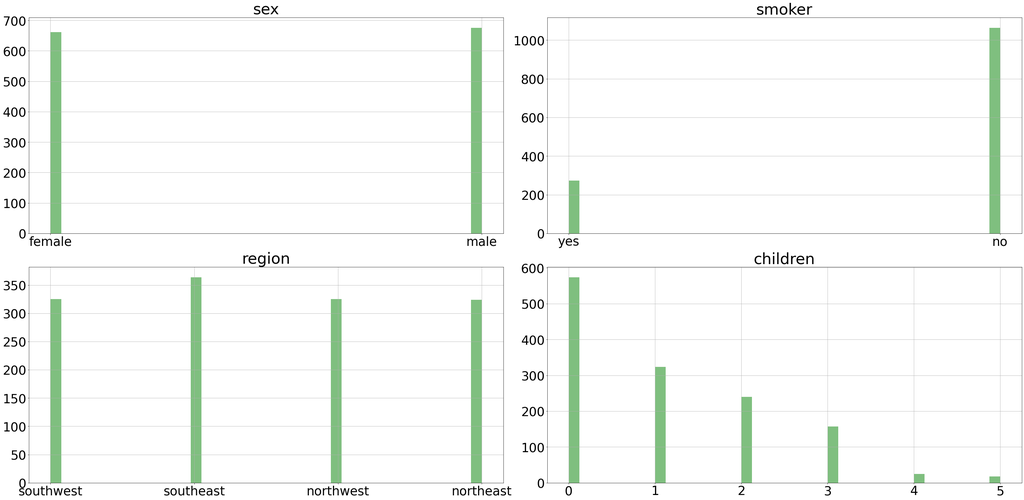

```python
# Distribution of categorical columns (include children) (4 marks

'''Extracting categorical variables first'''
num_merged = data.select_dtypes(include = ['object'])
num_merged["children"] = data["children"]
display(num_merged.head(3))
print('\n')
display(num_merged.columns.values)
draw_histograms(num_merged, num_merged.columns, 19, 2)
```

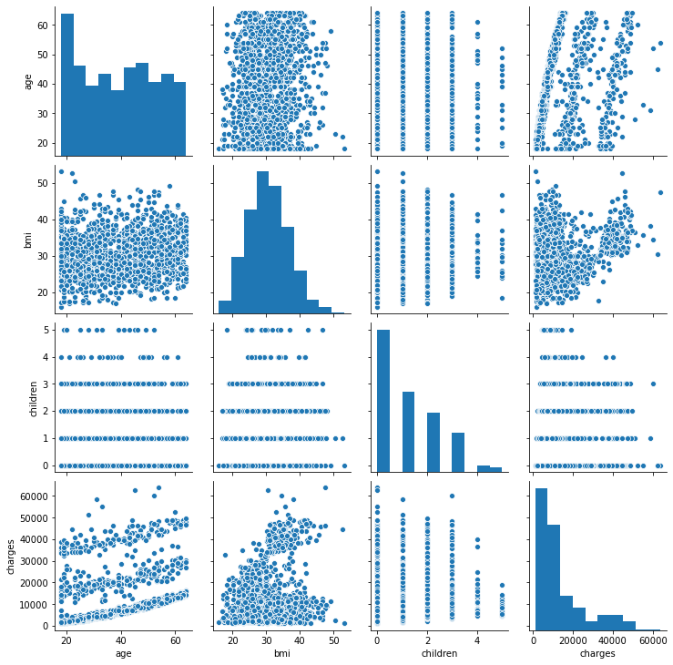

```python
# i.Pair plot that includes all the columns of the data frame (4 marks)
sns.pairplot(data)
```